# R Beginners Course 2026

Introduction to R and Basic Programming Concepts

Bioinformatics Core Facility CECAD

2026-05-21

## Slides & Code

[figure not shown]

- *[f]* Full screen
- *[o]* Slide Overview
- *[c]* Notes
- *[h]* help

### git repo

[R-Basic](https://github.com/CECADBioinformaticsCoreFacility/Beginners_R_Course_2026)

### Clone repo

`git clone https://github.com/CECADBioinformaticsCoreFacility/Beginners_R_Course_2026.git`

### Slides Directly

https://cecadbioinformaticscorefacility.github.io/Beginners_R_Course_2026/

**Session 6 :: Descriptive Statistics**

## What is Descriptive Statistics ?

descriptive statistics (in the broad sense of the term) is a branch of statistics aiming at summarizing, describing and presenting a series of values or a dataset.

There exists many measures to summarize a dataset. They are broadly divided into three types:

- Central Tendency
  - Mean, median, and mode
- Variability
  - Range, variance, and standard deviation
- Distribution
  - Modality, Skewness, Kurtosis

## Measures of Central Tendency

### mean, median, mode

```r
mean(iris$Sepal.Width)
```

```
[1] 3.057333
```

```r
median(iris$Sepal.Width)
```

```
[1] 3
```

```r
x <- table(iris$Sepal.Width)
sort(x, decreasing = TRUE)
```

```
  3 2.8 3.2 3.4 3.1 2.9 2.7 2.5 3.3 3.5 3.8 2.6 2.3 3.6 2.2 2.4 3.7 3.9   2   4
 26  14  13  12  11  10   9   8   6   6   6   5   4   4   3   3   3   2   1   1
4.1 4.2 4.4
  1   1   1
```

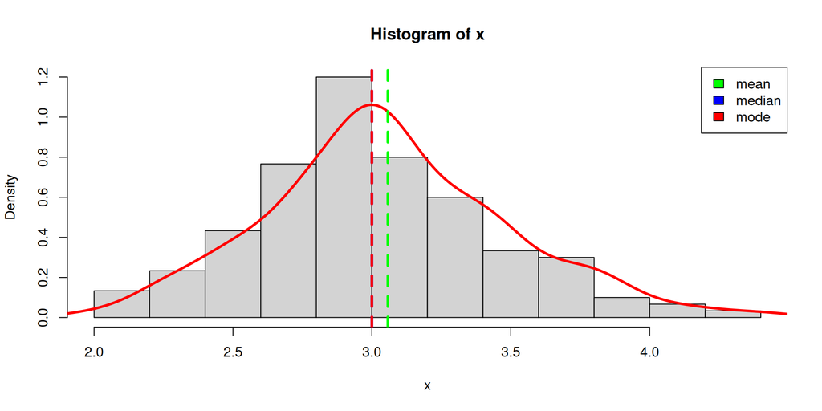

## Measures of Variability

### Min, max, range

```r
min(iris$Sepal.Length)
```

```
[1] 4.3
```

```r
max(iris$Sepal.Length)
```

```
[1] 7.9
```

```r
range(iris$Sepal.Length)
```

```
[1] 4.3 7.9
```

### Variance

```r
# variance
var(iris$Sepal.Length)
```

```
[1] 0.6856935
```

### Standard Deviation

```r
# standard deviation
sd(iris$Sepal.Length)
```

```
[1] 0.8280661
```

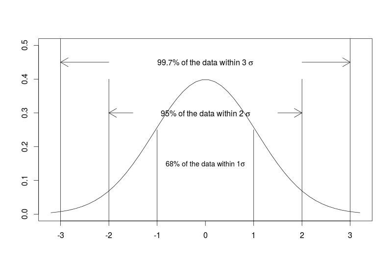

## Measures of Distribution

### Modes

The modality of a distribution is determined by the number of peaks it contains

### Skewness

Skewness is a measurement of the symmetry of a distribution.

```r
x<-iris$Sepal.Width
sum((x-mean(x))^3)/((length(x)-1)*sd(x)^3)
```

```
[1] 0.3147128
```

### Kurtosis

Kurtosis measures whether your dataset is heavy-tailed or light-tailed compared to a normal distribution.

```r
sum((x-mean(x))^4)/((length(x)-1)*sd(x)^4)
```

```
[1] 3.15977
```

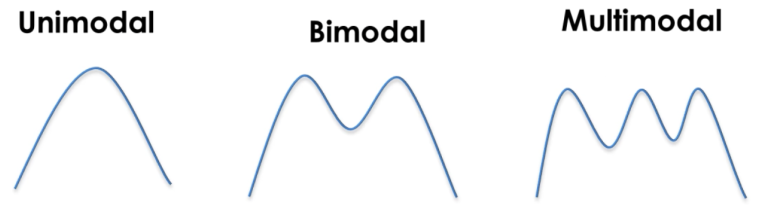

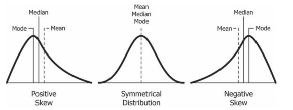

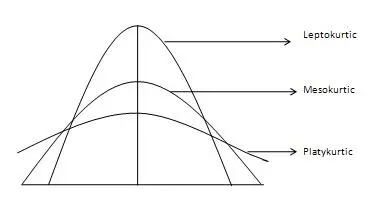

```r
#library(moments)
```

## Descriptive Statistics

- quartiles
- Summary
- Plot

```r
quantile(iris$Sepal.Length, 0.25) # first quartile
```

```
25%
5.1
```

```r
quantile(iris$Sepal.Length, 0.75) # third quartile
```

```
75%
6.4
```

```r
IQR(iris$Sepal.Length) # interquartile range
```

```
[1] 1.3
```

```r
summary(iris)
```

```
  Sepal.Length    Sepal.Width     Petal.Length    Petal.Width
 Min.   :4.300   Min.   :2.000   Min.   :1.000   Min.   :0.100
 1st Qu.:5.100   1st Qu.:2.800   1st Qu.:1.600   1st Qu.:0.300
 Median :5.800   Median :3.000   Median :4.350   Median :1.300
 Mean   :5.843   Mean   :3.057   Mean   :3.758   Mean   :1.199
 3rd Qu.:6.400   3rd Qu.:3.300   3rd Qu.:5.100   3rd Qu.:1.800
 Max.   :7.900   Max.   :4.400   Max.   :6.900   Max.   :2.500
       Species
 setosa    :50
 versicolor:50
 virginica :50
```

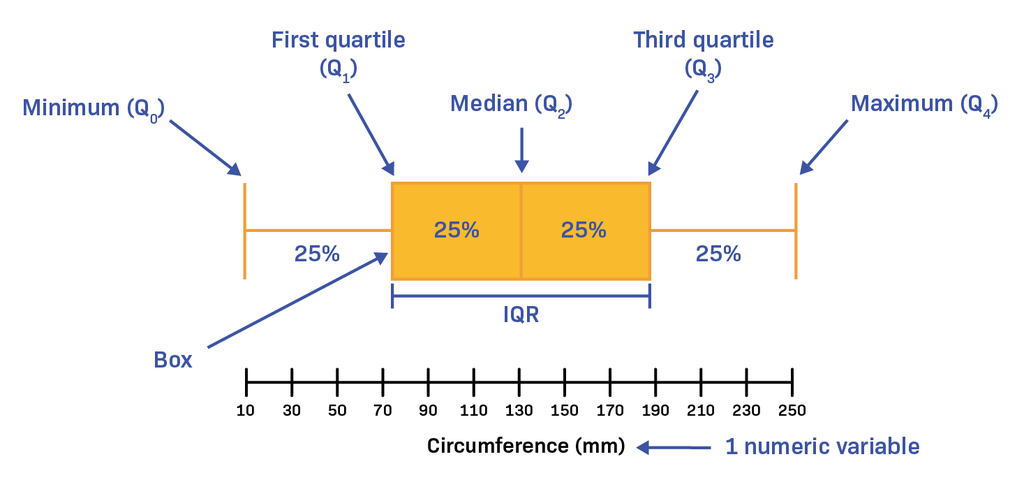

[How to Interpret Boxplots](https://www.labxchange.org/library/items/lb:LabXchange:d8863c77:html:1)

## Frequency/Cross/Contingency Tables

Cross-tabulation analysis, also known as contingency table analysis, is most often used to analyze categorical (nominal measurement scale) data.

At their core, cross-tabulations are simply data tables that present the results of the entire group of respondents, as well as results from subgroups of survey respondents. With them, you can examine relationships within the data that might not be readily apparent when only looking at total survey responses

```r
demo_data <- iris

demo_data$size <-
    ifelse(demo_data$Sepal.Length <
                            median(demo_data$Sepal.Length),
  "small", "big"
)
table(demo_data$Species, demo_data$size)
```

```
             big small
  setosa       1    49
  versicolor  29    21
  virginica   47     3
```

## Correlation

Correlation measures the relationship between two variables if they are linked to each other. It denotes if variables evolve in the same direction, in the opposite direction, or are independent.

- Correlation is usually computed on two quantitative variables, but it can also be computed on two qualitative ordinal variables.
- Pearson correlation is often used for quantitative continuous variables that have a linear relationship
- Spearman correlation (which is actually similar to Pearson but based on the ranked values for each variable rather than on the raw data) is often used to evaluate relationships involving at least one qualitative ordinal variable or two quantitative variables if the link is partially linear

```r
cor(iris$Sepal.Length,iris$Sepal.Width, method = "pearson")
```

```
[1] -0.1175698
```

```r
cor(iris$Sepal.Length,iris$Sepal.Width, method = "spearman")
```

```
[1] -0.1667777
```

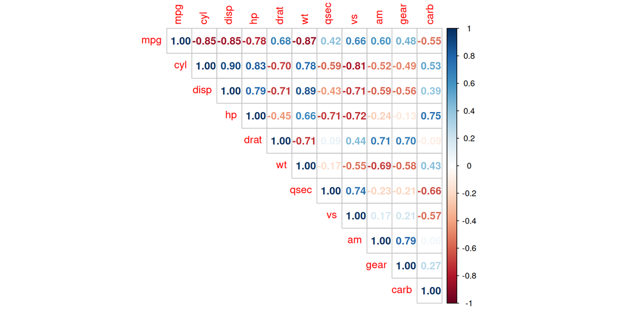

## Correlation Test

a correlation coefficient different from `0` in the sample does not mean that the correlation is significantly different from `0` in the population. This needs to be tested with a hypothesis test—and known as the correlation test.

The null and alternative hypothesis for the correlation test are as follows:

- *H*<sub>0</sub> : ρ = 0 (meaning that there is no linear relationship between the two variables)
- *H*<sub>1</sub> : ρ ≠ 0 (meaning that there is a linear relationship between the two variables)

```r
cor.test(iris$Sepal.Length,iris$Sepal.Width)
```

```
    Pearson's product-moment correlation

data:  iris$Sepal.Length and iris$Sepal.Width
t = -1.4403, df = 148, p-value = 0.1519
alternative hypothesis: true correlation is not equal to 0
95 percent confidence interval:
 -0.27269325  0.04351158
sample estimates:
       cor
-0.1175698
```